# Time Series Analysis of Daily Steps Data

[figure not shown]

# Siyabonga Mahlangu- 223055539

# Predictive Analytics Assignment 2

# Table of Content

1.Introduction

2.Dataset

2.1Date

2.2Steps

2.3Goal

3.Methodology

3.1 Data Preparation

3.2 Exploratory Data Analysis

3.3 Test For Seasonality and Stationarity

3.4 Model Selection

3.5 Forecasting

3.6Reflection

# 1.Introduction

In this assignment, my goal is to thoroughly analyze a fitness dataset using time series analysis. I aim to identify significant patterns and trends in a person's daily step data over a specified period of time in order to gain useful insights into their physical activity routines. My main objective is to extract useful information from the dataset, which contains daily step measurements and other contextual data, by spotting patterns, spotting seasonal variations, and spotting anomalies that may help to improve and tailor the person's fitness regimen.

# 2.Dataset

2.1 Date: Each entry is linked to a particular date, allowing for a chronological list of measurements.

2.2 Steps: This variable represents the person's daily step count, which is the primary indicator of physical activity.

2.3 Goal: The "Goal" variable denotes the user's daily step target, providing a standard against which to gauge their development.

# 3.Methodology

## 3.1Data Preparation

```python
import pandas as pd

import numpy as np

import scipy.stats as stats

import os

import matplotlib.pyplot as plt

import plotly.express as px

%matplotlib inline

from datetime import datetime

import datetime as d


from statsmodels.tsa.seasonal import seasonal_decompose

from statsmodels.tsa.stattools import adfuller

from statsmodels.tsa.arima_model import ARIMA

from sklearn.metrics import mean_squared_error

for filename in os.listdir(r'C:\Users\Siyabonga.Mahlangu\3D Objects\Siyabonga_Mahlangu_Dataset'):
    if filename.endswith('.csv'):
        file_path = os.path.join(r'C:\Users\Siyabonga.Mahlangu\3D Objects\Siyabonga_Mahlangu_Dataset', filename)



dataframes = []  # Create an empty list to hold DataFrame objects

for filename in os.listdir(r'C:\Users\Siyabonga.Mahlangu\3D Objects\Siyabonga_Mahlangu_Dataset'):
    if filename.endswith('.csv'):
        file_path = os.path.join(r'C:\Users\Siyabonga.Mahlangu\3D Objects\Siyabonga_Mahlangu_Dataset', filename)
        df = pd.read_csv(file_path)  # Read the CSV file into a DataFrame
        dataframes.append(df)  # Append the DataFrame to the list

# Concatenate all DataFrames in the list
steps_data= pd.concat(dataframes, ignore_index=True)
```

```python
steps_data
```

|  | Date | Actual | Goal |
| --- | --- | --- | --- |
| 0 | May 31 2022 | 0 | 8000 |
| 1 | Jun 1 2022 | 0 | 8000 |
| 2 | Jun 2 2022 | 0 | 8000 |
| 3 | Jun 3 2022 | 1102 | 8000 |
| 4 | Jun 4 2022 | 1254 | 8000 |
| ... | ... | ... | ... |
| 415 | Feb 2 2023 | 4969 | 8000 |
| 416 | Feb 3 2023 | 4979 | 8000 |
| 417 | Feb 4 2023 | 1441 | 8000 |
| 418 | Feb 5 2023 | 3025 | 8000 |
| 419 | Feb 6 2023 | 3956 | 8000 |

420 rows × 3 columns

## 3.2 Exploratory Data Analysis

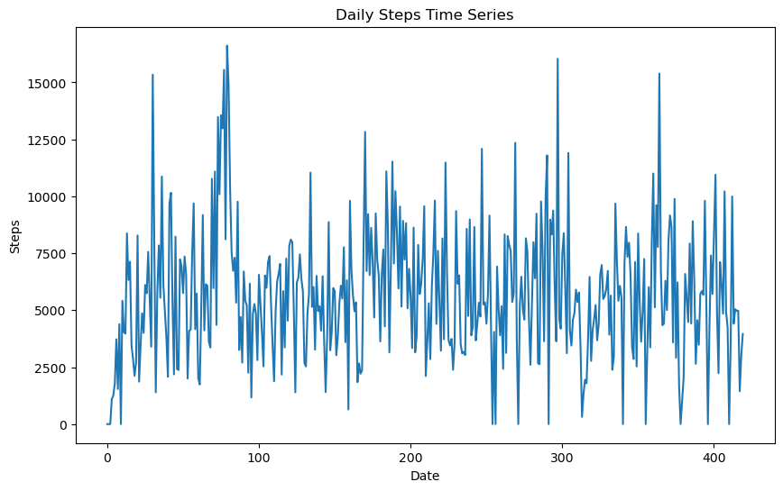

```python
# Plot the time series
plt.figure(figsize=(10, 6))
plt.plot(steps_data["Actual"])
plt.title("Daily Steps Time Series")
plt.xlabel("Date")
plt.ylabel("Steps")
plt.show()
```

## descriptive statistics

```python
mean_steps = steps_data["Actual"].mean()
median_steps = steps_data["Actual"].median()
std_steps = steps_data["Actual"].std()

print("Mean steps:", mean_steps)
print("Median steps:", median_steps)
print("Standard Deviation of steps:", std_steps)
```

```
Mean steps: 5674.140476190476
Median steps: 5402.0
Standard Deviation of steps: 2930.5654389000065
```

# 3.3 Test for Seasonality and Stationarity

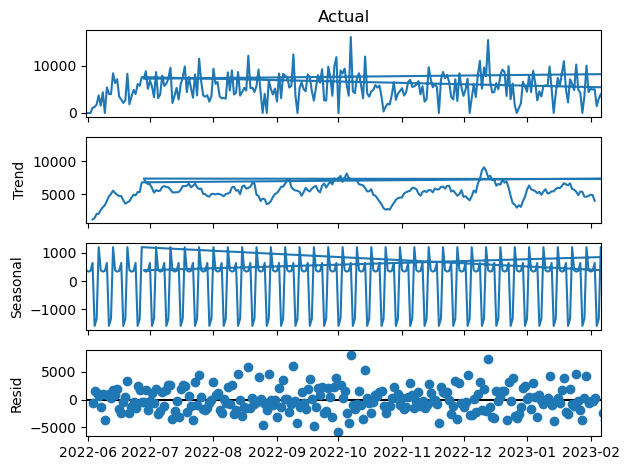

```python
# Plot decomposed components
result.plot()
plt.show()
```

# Interpretation:

Trend: The time series overall direction is highlighted by the trend component. A trend going down signifies a decrease in daily steps whereas a trend going up suggests an increase over time.

Seasonal: The seasonal component of the time series indicates recurrent trends. Seasonality is evident if you observe recurring spikes at specific times.The spikes going down shows that the Individual was relaxed so it's either he was at the office or chilling at home, and the spikes going down might indicate that it was weeekends

Residual:Remaining noise or abnormalities are captured by the residual component, which subtracts trend and seasonality. A residual that appears random suggests that the time series is well-decomposed, whereas any structured pattern can suggest that the data contains unexplained patterns.

# Perform Augmented Dickey-Fuller test

```python
adf_result = adfuller(steps_data["Goal"])
print("ADF Test Statistic:", adf_result[0])
print("p-value:", adf_result[1])
print("Critical Values:", adf_result[4])
```

```
ADF Test Statistic: -1.7308624567608497
p-value: 0.4152854382371029
Critical Values: {'1%': -3.4460536145702383, '5%': -2.868462751982839, '10%': -2.570457599182051}
```